# Mine_or_Rock Identitifcation and Classification

```python
import numpy as np
import pandas as pd
from sklearn import metrics
from sklearn.preprocessing import StandardScaler
from sklearn.metrics import accuracy_score, confusion_matrix,classification_report
import matplotlib.pyplot as plt
```

```python
sonar_df=pd.read_excel("mine_vs_rock.xlsx",header=None)
sonar_df.head()
```

|  | 0 | 1 | 2 | 3 | 4 | 5 | 6 | 7 | 8 | 9 | ... | 51 | 52 | 53 | 54 | 55 | 56 | 57 | 58 | 59 | 60 |
| --- | --- | --- | --- | --- | --- | --- | --- | --- | --- | --- | --- | --- | --- | --- | --- | --- | --- | --- | --- | --- | --- |
| 0 | 0.0200 | 0.0371 | 0.0428 | 0.0207 | 0.0954 | 0.0986 | 0.1539 | 0.1601 | 0.3109 | 0.2111 | ... | 0.0027 | 0.0065 | 0.0159 | 0.0072 | 0.0167 | 0.0180 | 0.0084 | 0.0090 | 0.0032 | R |
| 1 | 0.0453 | 0.0523 | 0.0843 | 0.0689 | 0.1183 | 0.2583 | 0.2156 | 0.3481 | 0.3337 | 0.2872 | ... | 0.0084 | 0.0089 | 0.0048 | 0.0094 | 0.0191 | 0.0140 | 0.0049 | 0.0052 | 0.0044 | R |
| 2 | 0.0262 | 0.0582 | 0.1099 | 0.1083 | 0.0974 | 0.2280 | 0.2431 | 0.3771 | 0.5598 | 0.6194 | ... | 0.0232 | 0.0166 | 0.0095 | 0.0180 | 0.0244 | 0.0316 | 0.0164 | 0.0095 | 0.0078 | R |
| 3 | 0.0100 | 0.0171 | 0.0623 | 0.0205 | 0.0205 | 0.0368 | 0.1098 | 0.1276 | 0.0598 | 0.1264 | ... | 0.0121 | 0.0036 | 0.0150 | 0.0085 | 0.0073 | 0.0050 | 0.0044 | 0.0040 | 0.0117 | R |
| 4 | 0.0762 | 0.0666 | 0.0481 | 0.0394 | 0.0590 | 0.0649 | 0.1209 | 0.2467 | 0.3564 | 0.4459 | ... | 0.0031 | 0.0054 | 0.0105 | 0.0110 | 0.0015 | 0.0072 | 0.0048 | 0.0107 | 0.0094 | R |

5 rows × 61 columns

```python
sonar_df=pd.read_csv('/content/drive/MyDrive/mine_vs_rock.csv',header=None)
sonar_df.head()
```

|  | 0 | 1 | 2 | 3 | 4 | 5 | 6 | 7 | 8 | 9 | ... | 51 | 52 | 53 | 54 | 55 | 56 | 57 | 58 | 59 | 60 |
| --- | --- | --- | --- | --- | --- | --- | --- | --- | --- | --- | --- | --- | --- | --- | --- | --- | --- | --- | --- | --- | --- |
| 0 | 0.0200 | 0.0371 | 0.0428 | 0.0207 | 0.0954 | 0.0986 | 0.1539 | 0.1601 | 0.3109 | 0.2111 | ... | 0.0027 | 0.0065 | 0.0159 | 0.0072 | 0.0167 | 0.0180 | 0.0084 | 0.0090 | 0.0032 | R |
| 1 | 0.0453 | 0.0523 | 0.0843 | 0.0689 | 0.1183 | 0.2583 | 0.2156 | 0.3481 | 0.3337 | 0.2872 | ... | 0.0084 | 0.0089 | 0.0048 | 0.0094 | 0.0191 | 0.0140 | 0.0049 | 0.0052 | 0.0044 | R |
| 2 | 0.0262 | 0.0582 | 0.1099 | 0.1083 | 0.0974 | 0.2280 | 0.2431 | 0.3771 | 0.5598 | 0.6194 | ... | 0.0232 | 0.0166 | 0.0095 | 0.0180 | 0.0244 | 0.0316 | 0.0164 | 0.0095 | 0.0078 | R |
| 3 | 0.0100 | 0.0171 | 0.0623 | 0.0205 | 0.0205 | 0.0368 | 0.1098 | 0.1276 | 0.0598 | 0.1264 | ... | 0.0121 | 0.0036 | 0.0150 | 0.0085 | 0.0073 | 0.0050 | 0.0044 | 0.0040 | 0.0117 | R |
| 4 | 0.0762 | 0.0666 | 0.0481 | 0.0394 | 0.0590 | 0.0649 | 0.1209 | 0.2467 | 0.3564 | 0.4459 | ... | 0.0031 | 0.0054 | 0.0105 | 0.0110 | 0.0015 | 0.0072 | 0.0048 | 0.0107 | 0.0094 | R |

5 rows × 61 columns

```python
sonar_df.isnull()
```

|  | 0 | 1 | 2 | 3 | 4 | 5 | 6 | 7 | 8 | 9 | ... | 51 | 52 | 53 | 54 | 55 | 56 | 57 | 58 | 59 | 60 |
| --- | --- | --- | --- | --- | --- | --- | --- | --- | --- | --- | --- | --- | --- | --- | --- | --- | --- | --- | --- | --- | --- |
| 0 | False | False | False | False | False | False | False | False | False | False | ... | False | False | False | False | False | False | False | False | False | False |
| 1 | False | False | False | False | False | False | False | False | False | False | ... | False | False | False | False | False | False | False | False | False | False |
| 2 | False | False | False | False | False | False | False | False | False | False | ... | False | False | False | False | False | False | False | False | False | False |
| 3 | False | False | False | False | False | False | False | False | False | False | ... | False | False | False | False | False | False | False | False | False | False |
| 4 | False | False | False | False | False | False | False | False | False | False | ... | False | False | False | False | False | False | False | False | False | False |
| ... | ... | ... | ... | ... | ... | ... | ... | ... | ... | ... | ... | ... | ... | ... | ... | ... | ... | ... | ... | ... | ... |
| 203 | False | False | False | False | False | False | False | False | False | False | ... | False | False | False | False | False | False | False | False | False | False |
| 204 | False | False | False | False | False | False | False | False | False | False | ... | False | False | False | False | False | False | False | False | False | False |
| 205 | False | False | False | False | False | False | False | False | False | False | ... | False | False | False | False | False | False | False | False | False | False |
| 206 | False | False | False | False | False | False | False | False | False | False | ... | False | False | False | False | False | False | False | False | False | False |
| 207 | False | False | False | False | False | False | False | False | False | False | ... | False | False | False | False | False | False | False | False | False | False |

208 rows × 61 columns

```python
sonar_df.duplicated()
```

```
0      False
1      False
2      False
3      False
4      False
       ...
203    False
204    False
205    False
206    False
207    False
Length: 208, dtype: bool
```

```python
sonar_df.describe()
```

|  | 0 | 1 | 2 | 3 | 4 | 5 | 6 | 7 | 8 | 9 | ... | 50 | 51 | 52 | 53 | 54 | 55 | 56 | 57 | 58 | 59 |
| --- | --- | --- | --- | --- | --- | --- | --- | --- | --- | --- | --- | --- | --- | --- | --- | --- | --- | --- | --- | --- | --- |
| count | 208.000000 | 208.000000 | 208.000000 | 208.000000 | 208.000000 | 208.000000 | 208.000000 | 208.000000 | 208.000000 | 208.000000 | ... | 208.000000 | 208.000000 | 208.000000 | 208.000000 | 208.000000 | 208.000000 | 208.000000 | 208.000000 | 208.000000 | 208.000000 |
| mean | 0.029164 | 0.038437 | 0.043832 | 0.053892 | 0.075202 | 0.104570 | 0.121747 | 0.134799 | 0.178003 | 0.208259 | ... | 0.016069 | 0.013420 | 0.010709 | 0.010941 | 0.009290 | 0.008222 | 0.007820 | 0.007949 | 0.007941 | 0.006507 |
| std | 0.022991 | 0.032960 | 0.038428 | 0.046528 | 0.055552 | 0.059105 | 0.061788 | 0.085152 | 0.118387 | 0.134416 | ... | 0.012008 | 0.009634 | 0.007060 | 0.007301 | 0.007088 | 0.005736 | 0.005785 | 0.006470 | 0.006181 | 0.005031 |
| min | 0.001500 | 0.000600 | 0.001500 | 0.005800 | 0.006700 | 0.010200 | 0.003300 | 0.005500 | 0.007500 | 0.011300 | ... | 0.000000 | 0.000800 | 0.000500 | 0.001000 | 0.000600 | 0.000400 | 0.000300 | 0.000300 | 0.000100 | 0.000600 |
| 25% | 0.013350 | 0.016450 | 0.018950 | 0.024375 | 0.038050 | 0.067025 | 0.080900 | 0.080425 | 0.097025 | 0.111275 | ... | 0.008425 | 0.007275 | 0.005075 | 0.005375 | 0.004150 | 0.004400 | 0.003700 | 0.003600 | 0.003675 | 0.003100 |
| 50% | 0.022800 | 0.030800 | 0.034300 | 0.044050 | 0.062500 | 0.092150 | 0.106950 | 0.112100 | 0.152250 | 0.182400 | ... | 0.013900 | 0.011400 | 0.009550 | 0.009300 | 0.007500 | 0.006850 | 0.005950 | 0.005800 | 0.006400 | 0.005300 |
| 75% | 0.035550 | 0.047950 | 0.057950 | 0.064500 | 0.100275 | 0.134125 | 0.154000 | 0.169600 | 0.233425 | 0.268700 | ... | 0.020825 | 0.016725 | 0.014900 | 0.014500 | 0.012100 | 0.010575 | 0.010425 | 0.010350 | 0.010325 | 0.008525 |
| max | 0.137100 | 0.233900 | 0.305900 | 0.426400 | 0.401000 | 0.382300 | 0.372900 | 0.459000 | 0.682800 | 0.710600 | ... | 0.100400 | 0.070900 | 0.039000 | 0.035200 | 0.044700 | 0.039400 | 0.035500 | 0.044000 | 0.036400 | 0.043900 |

8 rows × 60 columns

creating two new DataFrames, one containing rows where the value in column 60 is 'R' and the other containing rows where the value in column 60 is 'M'.

```python
df=sonar_df
df0 = df[df[60] == 'R']
df1 = df[df[60] == 'M']
```

```python
print("Number of samples in:")
print("Class label R - ", len(df0))
print("Class label M - ", len(df1))

df0 = df0.sample(len(df1), replace = True)

print('\nAfter resampling - ')
print("Number of samples in:")
print("Class label R - ", len(df0))
print("Class label M - ", len(df1))
```

```
Number of samples in:
Class label R -  97
Class label M -  111

After resampling -
Number of samples in:
Class label R -  111
Class label M -  111
```

This line of code is sampling rows from df0 (which contains rows where the value in column 60 is 'R') to match the length of df1 (which contains rows where the value in column 60 is 'M'). The replace=True argument indicates that sampling is done with replacement, meaning that the same row can be sampled multiple times.

*The sample() function is used to randomly select a subset of rows from the DataFrame df0. The len(df1) argument specifies the number of rows to sample, which is the same as the length of DataFrame df1. The replace=True argument indicates that sampling is done with replacement, meaning that the same row can be selected multiple times. This is useful for balancing the sizes of two datasets or for generating bootstrap samples in statistical analysis.

* When you sample from a DataFrame using the sample() function in pandas with replacement (i.e., replace=True), the sampled rows are not added to the original DataFrame. Instead, the sampled rows are used to create a new DataFrame.

```python
df = df1.append(df0)
print('Total number of samples - ', len(df))
```

```
Total number of samples -  222
```

```python
np.shape(df)
```

```
(222, 61)
```

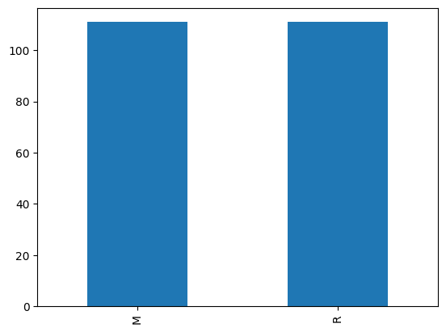

```python
df[60].value_counts().plot(kind='bar')
```

This line of code generates a bar plot showing the count of each unique value in column 60 of the DataFrame df.

Here's what each part of the code does:

df[60] selects column 60 from the DataFrame df. .value_counts() counts the occurrences of each unique value in column 60. .plot(kind='bar') creates a bar plot of the counts.

[output not shown]

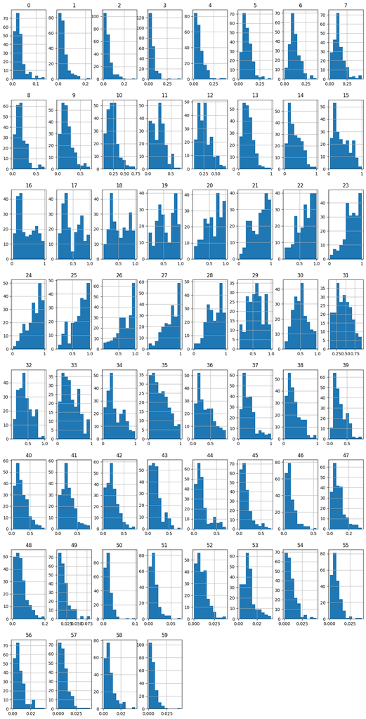

```python
fig = plt.figure(figsize = (15,30))
ax = fig.gca()
df.hist(ax = ax)
```

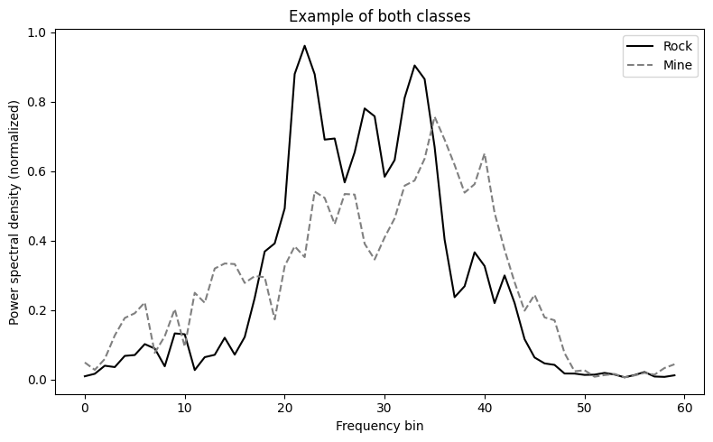

```python
plt.figure(figsize=(8,5))
plt.plot(df[df[60] == 'R'].values[0][:-1], label='Rock', color='black')
plt.plot(df[df[60] == 'M'].values[0][:-1], label='Mine', color='gray', linestyle='--')
plt.legend()
plt.title('Example of both classes')
plt.xlabel('Frequency bin')
plt.ylabel('Power spectral density (normalized)')
plt.tight_layout()
plt.show()
```

This line of code plots a line chart using data from rows in your DataFrame where the value in column 60 is 'R'.

breaking down the second line to understand:

*df[df[60] == 'R']: This filters the DataFrame df to select rows where the value in column 60 is 'R'.

*values[0][:-1]: This retrieves the values of the first row that meets the condition, excluding the last value (assuming the last value is the target label or class, as it's excluded here).

*label='Rock': This assigns the label 'Rock' to the line in the plot, which will be used in the legend.

*color='black': This sets the color of the line to black.

```python
X = df.drop(columns=60,axis=1)
Y = df[60]
print(X)
print(Y)
```

```
         0       1       2       3       4       5       6       7       8   \
97   0.0491  0.0279  0.0592  0.1270  0.1772  0.1908  0.2217  0.0768  0.1246
98   0.1313  0.2339  0.3059  0.4264  0.4010  0.1791  0.1853  0.0055  0.1929
99   0.0201  0.0423  0.0554  0.0783  0.0620  0.0871  0.1201  0.2707  0.1206
100  0.0629  0.1065  0.1526  0.1229  0.1437  0.1190  0.0884  0.0907  0.2107
101  0.0335  0.0134  0.0696  0.1180  0.0348  0.1180  0.1948  0.1607  0.3036
..      ...     ...     ...     ...     ...     ...     ...     ...     ...
12   0.0079  0.0086  0.0055  0.0250  0.0344  0.0546  0.0528  0.0958  0.1009
53   0.0293  0.0378  0.0257  0.0062  0.0130  0.0612  0.0895  0.1107  0.0973
68   0.0195  0.0142  0.0181  0.0406  0.0391  0.0249  0.0892  0.0973  0.0840
14   0.0124  0.0433  0.0604  0.0449  0.0597  0.0355  0.0531  0.0343  0.1052
10   0.0039  0.0063  0.0152  0.0336  0.0310  0.0284  0.0396  0.0272  0.0323

         9   ...      50      51      52      53      54      55      56  \
97   0.2028  ...  0.0268  0.0081  0.0129  0.0161  0.0063  0.0119  0.0194
```

[output cut: 37 more lines]

code is splitting the DataFrame df into features (X) and labels (Y).

*X = df.drop(columns=60, axis=1) - This line creates a new DataFrame X containing the features. It does this by dropping the column with index 60 (presumably the target label column) along the columns axis (axis=1).

*Y = df[60] - This line creates a new Series Y containing the target labels. It selects the column with index 60 from the original DataFrame df.

When axis=1, it refers to columns. Conversely, axis=0 would refer to rows. So, in the line X = df.drop(columns=60, axis=1), axis=1 indicates that you want to drop columns (not rows), specifically the column with index or label 60.

This allows you to remove a specific column from the DataFrame and retain the rest of the data for your analysis or modeling purposes.

```python
from sklearn.model_selection import train_test_split
X_train, X_test, Y_train, Y_test = train_test_split(X, Y, test_size=0.2, random_state=42)
```

*random_state=42: This parameter sets the random seed for reproducibility. Using the same random state ensures that the split is deterministic, meaning you'll get the same split each time you run the code.

After executing this line of code, you'll have four sets of data:

X_train: This contains the features for training the model.

X_test: This contains the features for testing the model.

Y_train: This contains the labels corresponding to the training features.

Y_test: This contains the labels corresponding to the testing features.

```python
from sklearn.linear_model import LogisticRegression
lr = LogisticRegression()
lr.fit(X_train,Y_train)
```

```
LogisticRegression()
```

```python
test_pred = lr.predict(X_test)
lra = accuracy_score(test_pred,Y_test)
print(lra)
```

```
0.782608695652174
```

This code segment predicts the labels for the testing data (X_test) using the trained logistic regression model (lr) and then calculates the accuracy of the predictions.

Here's what each part does:

*test_pred = lr.predict(X_test) - This line uses the trained logistic regression model lr to predict the labels for the testing data X_test. The predict() method takes the features of the testing data as input and returns the predicted labels.

*lra = accuracy_score(test_pred, Y_test) - This line calculates the accuracy of the predicted labels (test_pred) compared to the actual labels (Y_test). The accuracy_score() function from scikit-learn computes the accuracy by comparing the predicted labels to the true labels. It returns the proportion of correctly classified samples.

*print(lra) - This line prints the accuracy score (lra) to the console.

By comparing the predicted labels to the actual labels and calculating the accuracy, you can evaluate how well the logistic regression model performs on the testing data. The accuracy score indicates the proportion of correctly classified samples in the testing data.

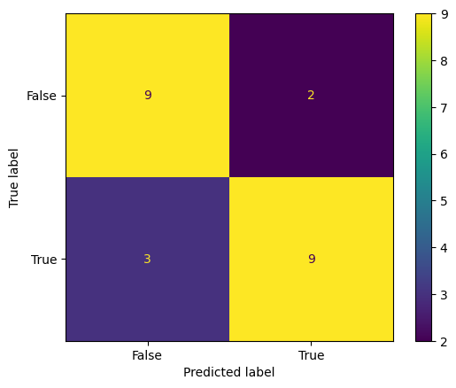

```python
cm = metrics.confusion_matrix(test_pred,Y_test)
cm_display = metrics.ConfusionMatrixDisplay(confusion_matrix = cm, display_labels = [False, True])
cm_display.plot()
plt.show()
```

```python
pd.crosstab(Y_test, test_pred, colnames=['Predicted'], margins=True)
```

| Predicted 60 | M | R | All |
| --- | --- | --- | --- |
| M | 9 | 3 | 12 |
| R | 2 | 9 | 11 |
| All | 11 | 12 | 23 |

```python
print(classification_report(test_pred, Y_test))
```

```
              precision    recall  f1-score   support

           M       0.75      0.82      0.78        11
           R       0.82      0.75      0.78        12

    accuracy                           0.78        23
   macro avg       0.78      0.78      0.78        23
weighted avg       0.79      0.78      0.78        23
```

```python
from sklearn.neighbors import KNeighborsClassifier
knn = KNeighborsClassifier(n_neighbors = 5)
knn.fit(X_train, Y_train)
```

```
KNeighborsClassifier()
```

```python
test_pred = knn.predict(X_test)
knna = accuracy_score(test_pred,Y_test)
print(knna)
```

```
0.9565217391304348
```

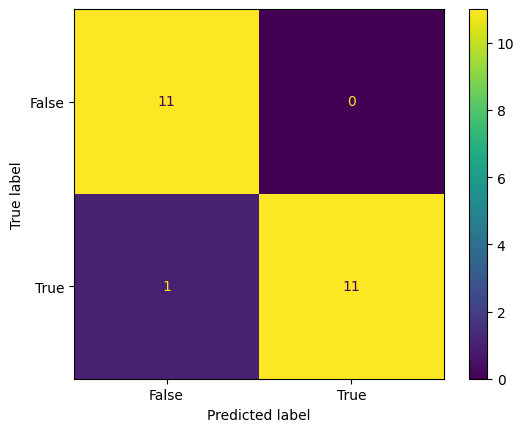

```python
cm = metrics.confusion_matrix(test_pred,Y_test)
cm_display = metrics.ConfusionMatrixDisplay(confusion_matrix = cm, display_labels = [False, True])
cm_display.plot()
plt.show()
```

```python
pd.crosstab(Y_test, test_pred, colnames=['Predicted'], margins=True)
```

| Predicted 60 | M | R | All |
| --- | --- | --- | --- |
| M | 11 | 1 | 12 |
| R | 0 | 11 | 11 |
| All | 11 | 12 | 23 |

```python
print(classification_report(test_pred, Y_test))
```

```
              precision    recall  f1-score   support

           M       0.92      1.00      0.96        11
           R       1.00      0.92      0.96        12

    accuracy                           0.96        23
   macro avg       0.96      0.96      0.96        23
weighted avg       0.96      0.96      0.96        23
```

```python
from sklearn.tree import DecisionTreeClassifier
dt = DecisionTreeClassifier(criterion = 'entropy')
dt.fit(X_train,Y_train)
```

```
DecisionTreeClassifier(criterion='entropy')
```

```python
test_pred = dt.predict(X_test)
dta = accuracy_score(test_pred,Y_test)
print(dta)
```

```
0.8260869565217391
```

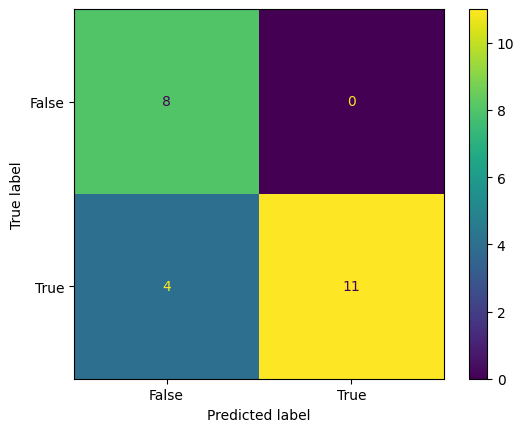

```python
cm = metrics.confusion_matrix(test_pred, Y_test)
cm_display = metrics.ConfusionMatrixDisplay(confusion_matrix = cm, display_labels = [False, True])
cm_display.plot()
plt.show()
```

```python
pd.crosstab(Y_test, test_pred, colnames=['Predicted'], margins=True)
```

| Predicted 60 | M | R | All |
| --- | --- | --- | --- |
| M | 8 | 4 | 12 |
| R | 0 | 11 | 11 |
| All | 8 | 15 | 23 |

```python
print(classification_report(test_pred, Y_test))
```

```
              precision    recall  f1-score   support

           M       0.67      1.00      0.80         8
           R       1.00      0.73      0.85        15

    accuracy                           0.83        23
   macro avg       0.83      0.87      0.82        23
weighted avg       0.88      0.83      0.83        23
```

```python
from sklearn.svm import SVC
svm = SVC(kernel = 'rbf')
svm.fit(X_train,Y_train)
```

```
SVC()
```

```python
test_pred = svm.predict(X_test)
svma = accuracy_score(test_pred,Y_test)
print(svma)
```

```
0.8695652173913043
```

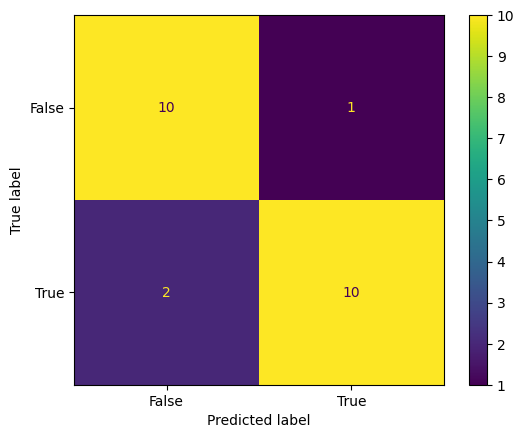

```python
cm = metrics.confusion_matrix(test_pred, Y_test)
cm_display = metrics.ConfusionMatrixDisplay(confusion_matrix = cm, display_labels = [False, True])
cm_display.plot()
plt.show()
```

```python
print(classification_report(test_pred, Y_test))
```

```
              precision    recall  f1-score   support

           M       0.83      0.91      0.87        11
           R       0.91      0.83      0.87        12

    accuracy                           0.87        23
   macro avg       0.87      0.87      0.87        23
weighted avg       0.87      0.87      0.87        23
```

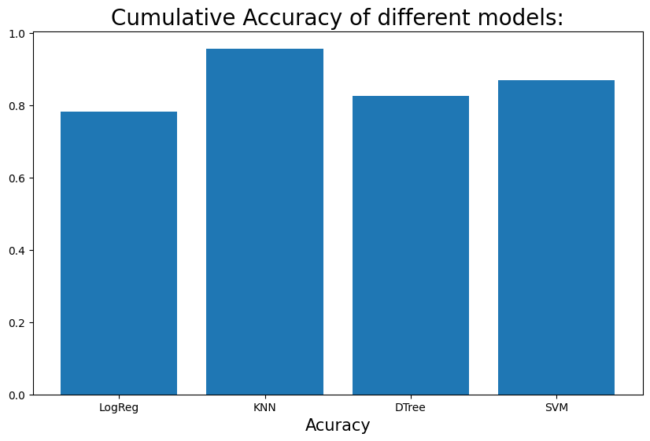

```python
plt.figure(figsize= (10,6))
acc = [lra,knna,dta,svma]
name = ['LogReg','KNN','DTree','SVM']
plt.title('Cumulative Accuracy of different models:', fontsize = 20)
plt.xlabel('Acuracy', fontsize = 15)
plt.bar(name,acc)
plt.show()
```

```python
input_data = (0.0201,0.0376,0.0438,0.0207,0.0954,0.0906,0.1539,0.1601,0.3109,0.2111,0.1609,0.1582,0.2238,0.0645,0.0660,0.2273,0.3100,0.2999,0.5078,0.4797,0.5783,0.5071,0.4328,0.5550,0.6711,0.6415,0.7104,0.8080,0.6791,0.3857,0.1307,0.2604,0.5121,0.7547,0.8537,0.8507,0.6692,0.6097,0.4943,0.2744,0.0510,0.2834,0.2825,0.4256,0.2641,0.1386,0.1051,0.1343,0.0383,0.0324,0.0232,0.0027,0.0065,0.0159,0.0072,0.0167,0.0180,0.0084,0.0090,0.0032)
input_data_np_array = np.asarray(input_data)
reshaped_input = input_data_np_array.reshape(1,-1)
prediction = knn.predict(reshaped_input)

if prediction[0] == 'R':
  print('The object is a Rock')
else:
  print('The object is a Mine')
```

```
The object is a Mine
```

*using a k-nearest neighbors (KNN) classifier (knn) to make predictions on some input data. After reshaping the input data into the appropriate format, predicting the class label and then printing out whether the predicted object is a rock or a mine based on the predicted label.

*input_data: Contains the features of the object you want to classify.

*input_data_np_array: Converts the input data into a NumPy array.

*reshaped_input: Reshapes the input data into a format suitable for prediction. In this case, it reshapes the input into a

*single sample with multiple features, so it becomes a 2D array with shape (1, n_features).

*prediction: Uses the trained KNN classifier (knn) to predict the class label for the reshaped input data.

Checks the predicted label and prints out whether the object is classified as a rock or a mine based on the predicted label